[figure not shown]

# Visualizing Data

Zhaoxia Yu

## Reminder

- Close all apps on your computer.
- Open slides for this session from the COSMOS website.

## Preparation

1. Load package named ‘ggplot2’ that used for visualization
2. Load tidyverse in order to refresh data wrangling
3. Load alzheimer_data

install/load ggplot2 and tidyverse

```r
#install.packages('ggplot2')
library(ggplot2)

#install.packages('tidyverse')
library(tidyverse)
```

load alzheimer_data

```r
# change the path to your personal folder path
alzheimer_data <- read.csv("../data/alzheimer_data.csv")
```

## Data

```r
glimpse(alzheimer_data)
```

```
Rows: 2,700
Columns: 57
$ id        <chr> "S060833", "S932623", "S755478", "S852291", "S011143", "S069…
$ diagnosis <int> 0, 0, 0, 0, 1, 0, 0, 2, 0, 2, 0, 0, 0, 1, 0, 1, 2, 2, 2, 1, …
$ age       <int> 74, 56, 77, 74, 75, 72, 64, 78, 73, 81, 66, 65, 66, 73, 78, …
$ educ      <int> 12, 16, 18, 20, 14, 16, 16, 17, 18, 13, 16, 16, 17, 20, 13, …
$ female    <int> 0, 1, 1, 1, 0, 1, 1, 0, 1, 0, 1, 1, 0, 1, 1, 1, 0, 0, 1, 1, …
$ height    <dbl> 65.0, 62.0, 65.0, 62.0, 62.0, 61.8, 60.0, 69.0, 65.0, 71.0, …
$ weight    <int> 233, 110, 137, 112, 127, 141, 124, 152, 131, 197, 134, 144, …
$ bpsys     <int> 148, 110, 144, 120, 145, 107, 112, 134, 122, 120, 150, 126, …
$ bpdias    <int> 100, 75, 60, 60, 61, 65, 70, 74, 60, 70, 85, 78, 60, 72, 80,…
$ hrate     <int> 72, 60, 64, 72, 58, 83, 76, 70, 60, 76, 60, 60, 76, 60, 68, …
$ cdrglob   <dbl> 0.5, 0.0, 0.0, 0.0, 0.5, 0.0, 0.0, 0.5, 0.0, 1.0, 0.0, 0.0, …
$ naccgds   <int> 5, 1, 0, 0, 4, 1, 2, 0, 0, 5, 0, 1, 0, 0, 0, 6, 3, 1, 3, 4, …
$ delsev    <int> 0, 0, 0, 0, 0, 0, 0, 0, 0, 0, 0, 0, 0, 0, 0, 0, 0, 0, 0, 0, …
```

[output cut: 44 more lines]

## ggplot

- **gg**plot is based on **g**rammar of **g**raphics.
- It is a powerful and flexible system for creating a wide range of visualizations.

[figure not shown]

## 3 steps of making a basic ggplot

1.Pick data

2.Map data onto aesthetics

3.Add the geometric layer

## Visualizing a Categorical Variable

Let’s check the number of patients in each diagnosis group.

## Step 1: Data

```r
ggplot(data = alzheimer_data)
```

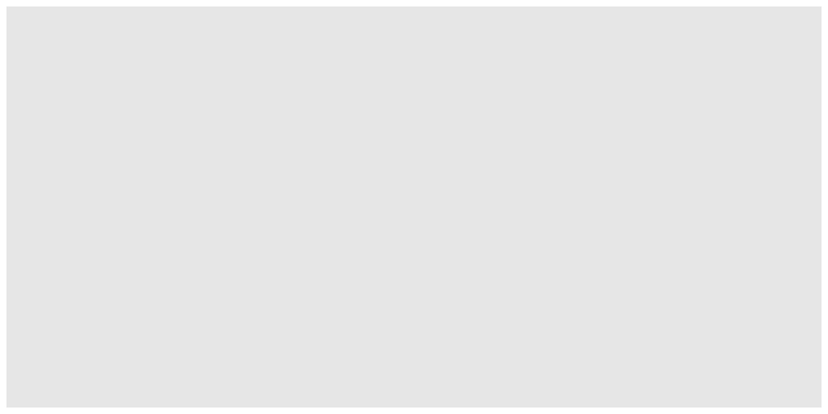

## Step 2: Map to Aesthetics

```r
ggplot(data = alzheimer_data,
       aes(x = diagnosis))
```

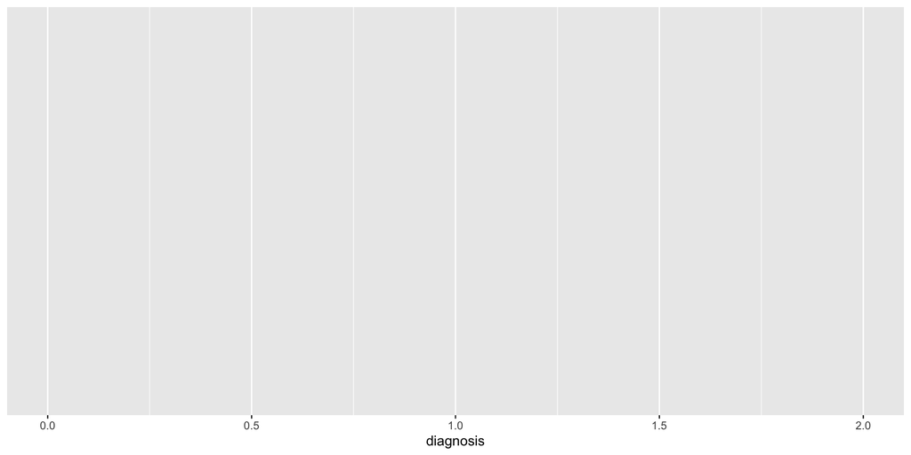

## Step 3: Add Geometric Layer with `+`

```r
ggplot(data = alzheimer_data,
       aes(x = diagnosis)) +
  geom_bar()
```

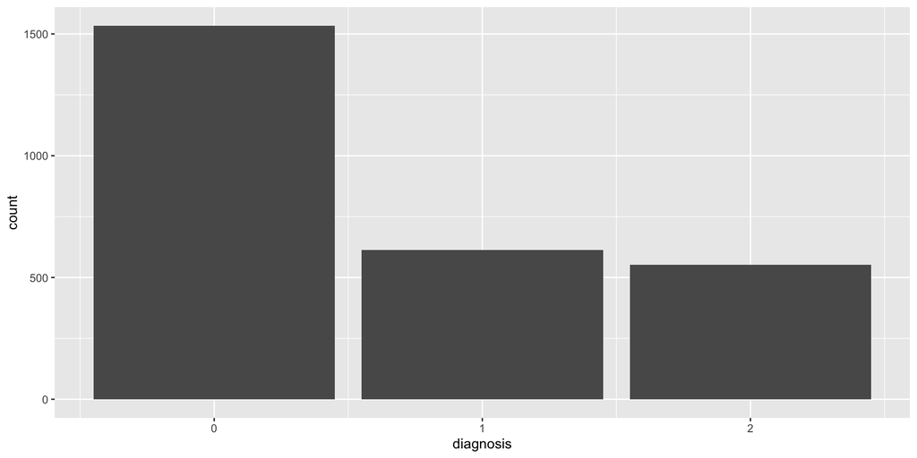

## Additional Features

1. Use pipe operator to feed the data to ggplot.

```r
alzheimer_data %>%
  ggplot(aes(x = diagnosis)) +
  geom_bar()
```

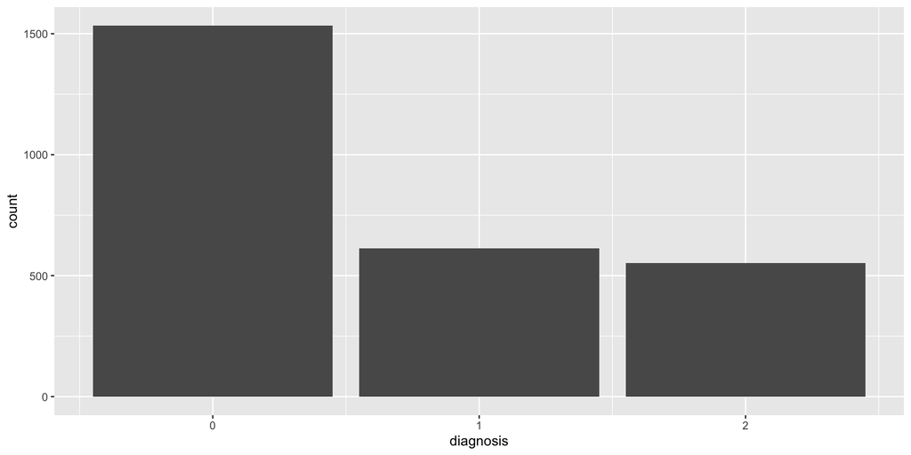

## Additional Features

2. Use `factor()` to add informative label to categorical variable (diagnosis)

Note: We will learn how to add labels to the axis later. Ignore `labs(), theme_minmial()` for now.

```r
# label diagnosis 0, 1, 2 to healthy, impaired, and Alzheimer's
alzheimer_data <- alzheimer_data %>%
  mutate(diagnosis_name = factor(diagnosis,
                            levels = c(0, 1, 2),
                            labels = c("Healthy", "Impaired", "Alzheimer's")))

alzheimer_data %>%
  ggplot(aes(x = diagnosis_name)) +
  geom_bar() +
  labs(
    title = "Count of Diagnosis Groups",
    x = "Diagnosis Type",
    y = "Count"
  )  +
  theme_minimal()
```

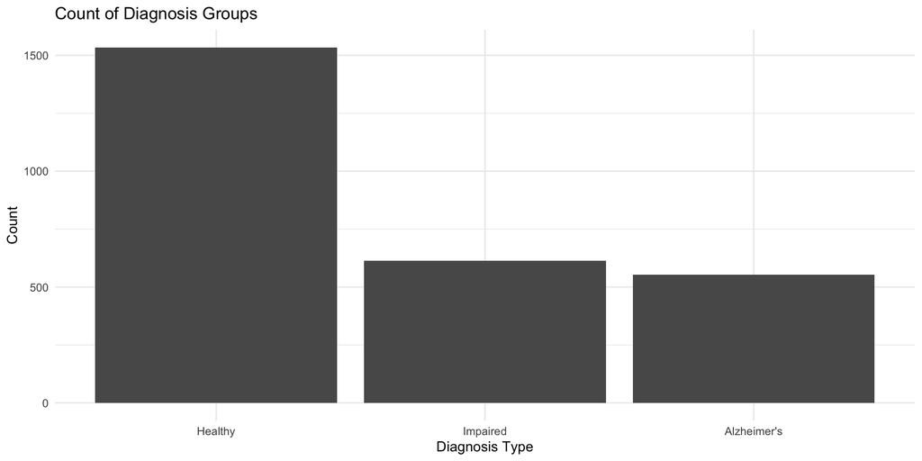

## Categorical by Categorical Variable

We can also use bar plot to visualize how the count of one categorical variable (e.g. gender) are distributed across the levels of another (e.g. diagnosis).

## Categorical by Categorical Variable

1. Stacked Bar Plot (Counts)

```r
# label female 0, 1 to male, female
alzheimer_data = alzheimer_data %>%
         mutate(female = factor(
           female,
           levels = c(0,1),
           labels = c("Male", "Female")))

alzheimer_data %>%
  ggplot(aes(x = female, fill = diagnosis_name)) +
  geom_bar(position = "stack") +
  labs(
    title = "Count of Diagnosis by Gender",
    x = "Gender",
    y = "Count",
    fill = "Diagnosis"
  ) +
  theme_minimal()
```

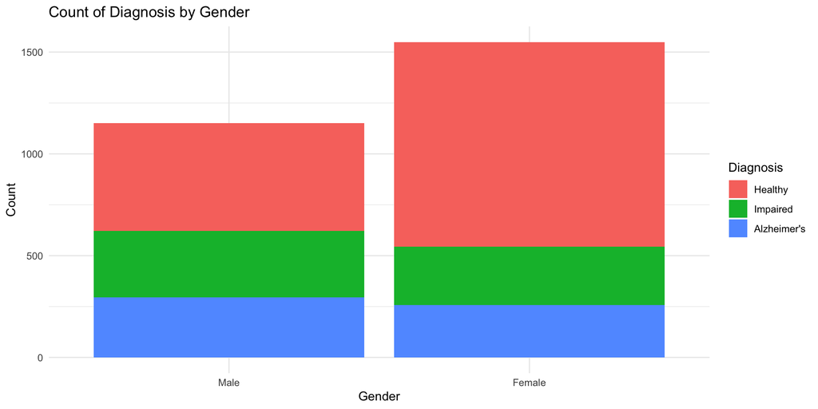

## Categorical by Categorical Variable

2. Grouped (Dodged) Bar Plot (Counts)

```r
ggplot(alzheimer_data, aes(x = female,
                          fill = diagnosis_name)) +
  geom_bar(position = "dodge") +
  labs(
    title = "Count of Diagnosis by Gender (Grouped)",
    x = "Gender",
    y = "Count",
    fill = "Diagnosis"
  ) +
  theme_minimal()
```

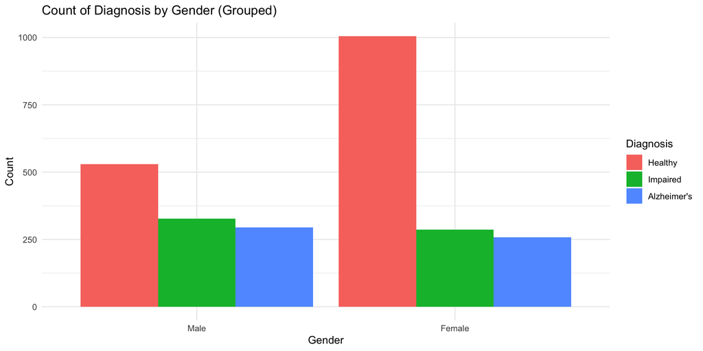

## Categorical by Categorical Variable

3. Proportions (Within Groups)

```r
alzheimer_data %>%
  ggplot(aes(x = female,fill = diagnosis_name)) +
  geom_bar(position = "fill") +  # Normalizes to 100% per group
  labs(
    title = "Proportion of Diagnosis by Gender",
    x = "Gender",
    y = "Proportion",
    fill = "Diagnosis"
  ) +
  theme_minimal()
```

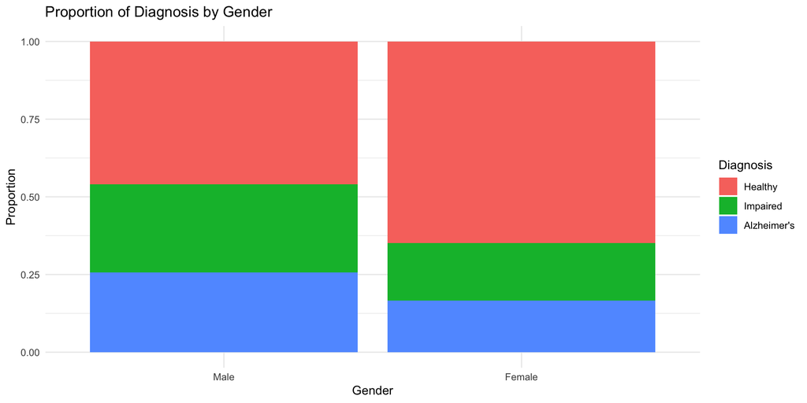